# Exploring Boston Police Stops Data

Practice with Categorical Variables

P. Lombardo

## Loading packages and data

```r
library(tidyverse)
bps<-read.csv('data/bps2.csv', header = T,
              stringsAsFactors = T)
```

Let’s consider an example using the Boston Police Stop Data from 2019. I retrieved this data from [boston.gov](https://www.boston.gov/civic-engagement/boston-police-accountability-and-transparency-data), specifically the [BPD FIO data](https://data.boston.gov/dataset/boston-police-department-fio)

- Those interested in similar analysis might find Dr. Matthew Ross’ article interesting: [Massachusetts Traffic Stops Analysis, 2014-2022](https://impactengines.northeastern.edu/project/mass-trafficstops-2023/)

## Our data

Let’s begin by exploring the data frame a bit.

What information do *you* want to know? Let’s brainstorm together:

- how many columns (variables), how many rows (observations)?
  - column names?
- Research Questions:
  - What time of day are you most likely pulled over?

OK, here are some commands to pull that information:

*I recommend you detail what each function does!*

```r
str(bps)
dim(bps)
nrow(bps)
ncol(bps)
names(bps)
```

## Considering Time of Day

Consider the `TimeOfDay` variable. What kind of relationship does this have to stops by the police?

Plan:

- Look at frequencies (counts) or relative frequencies (percents) for the `TimeOfDay` variable, and see which category has the highest frequency or relative frequency. This will indiciate what the data suggests is the most common time of day to be stopped by the police.

```r
# Place code here.
bps %>%
    select(TimeOfDay) %>%
    table()
```

```
## TimeOfDay
##      DayTime EarlyMorning    Nighttime
##         1140          609         1214
```

We can also create a visual:

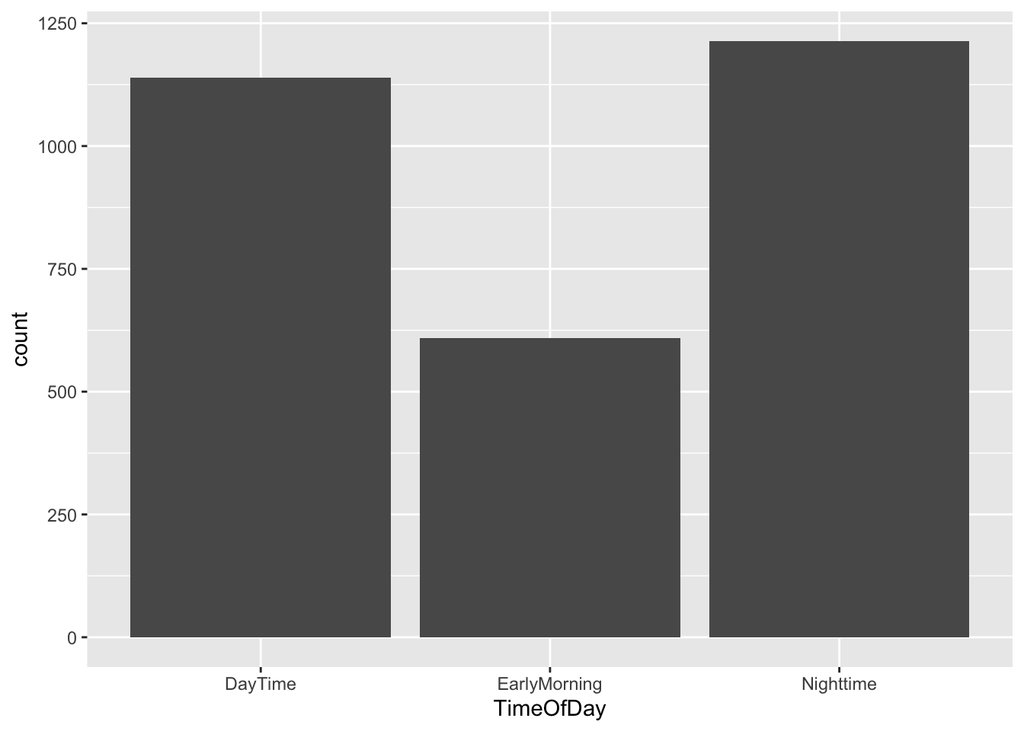

```r
ggplot(data = bps,
       aes(x = TimeOfDay))+
    geom_bar()
```

## Adding Age Demographics

Suppose we are interested in the mixture of age groups being pulled over at different times of day.

What kind of summary would help us think about this relationship? How will you interpret this summary table?

I will create a table that has the different age groups on the rows, and for each row we look at the percentage of each Time of Day (“row percentages”).

Create the table above using the `table()` command; we’ve set up a “shell” to fill in:

```r
# Place code here
bps %>%
    select(AgeGrp, TimeOfDay) %>%
    table() %>%
    # setting margin = 1 inside prop.table() makes sure we display the
    # row percentages (i.e. percentages of the different times of day for each age group)
    prop.table(margin = 1) %>%
    addmargins()
```

```
##          TimeOfDay
## AgeGrp       DayTime EarlyMorning  Nighttime        Sum
##   Adult   0.37494933   0.22496960 0.40008107 1.00000000
##   Minor   0.39933993   0.06270627 0.53795380 1.00000000
##   Senior  0.60000000   0.15000000 0.25000000 1.00000000
##   Unknown 0.30136986   0.23287671 0.46575342 1.00000000
##   Sum     1.67565913   0.67055258 1.65378829 4.00000000
```

*Note*: the `addmargins()` command will add row and column totals automatically. I like to use this to check that I used the correct margin. (You will see 1.00 in the row totals in this case.)

Create an appropriate visual and explain what it tells you about the relationship we are exploring. Once again, I provide a shell:

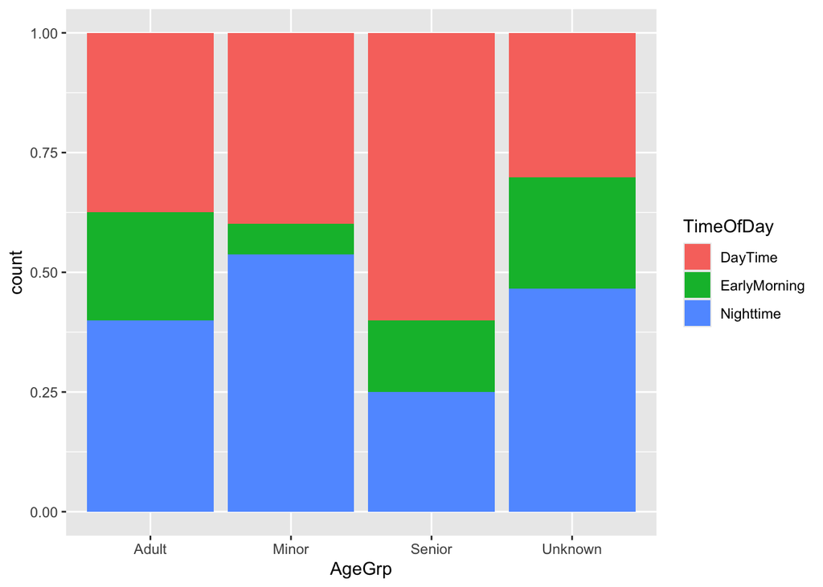

```r
#place code here. % 100%-stacked compares rates well
ggplot(data = bps,   # assign data frame
       aes(x = AgeGrp, fill = TimeOfDay))+    # set the main aesthetics
    geom_bar(position = "fill")    # add the geometry layer
```

**Exercise.** What does this plot tell us? *How* does it tell us that?

*This is an important exercise to do on your own. Make sure you know what a plot shows, **and how it shoes it!***.

Here is another possibility, a side-by-side bar-plot.

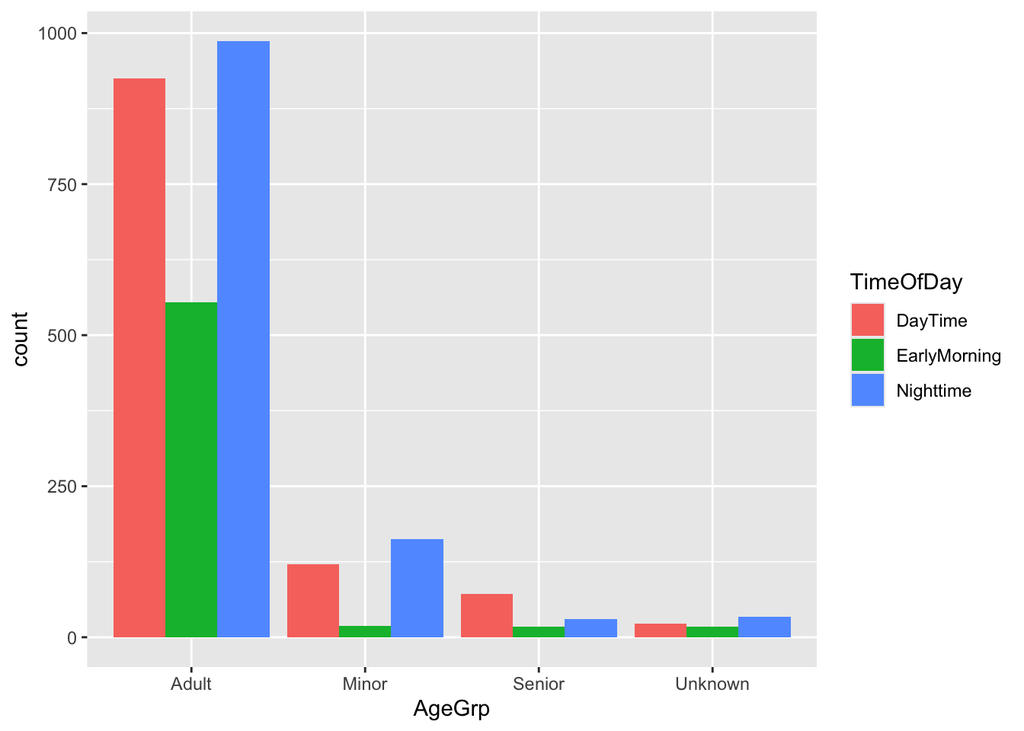

```r
#place code here.
ggplot(data = bps,   # assign data frame
       aes(x = AgeGrp, fill = TimeOfDay))+    # set the main aesthetics
    geom_bar(position = "dodge")    # add the geometry layer
```

**Exercise.** What does this plot tell us? *How* does it tell us that?

For each `AgeGrp`, we get bars indicating the number of stops during each `TimeOfDay`. In the *Adult* group and in the *Minor* group, night-time stops occurred more than the other times of day (the blue bar was highest among the other options). However, for *Senior*s, day-time stops were most prevalent.

*What other barplots could we have used? What would they show us?*

# Do your own exploration!

Pick two categorical variables from the `bps` data frame, and explore on your own or with a partner. Please

- Compute at least one table of counts or percentages, and interpret what “message” this table communicate to you.
- Compute at least one visual based on your summary table, and explain how this visual communicates the same “message”.

*This section was for your own practice!*

### (Optional) More ggplot modifications!

When names get cut off…

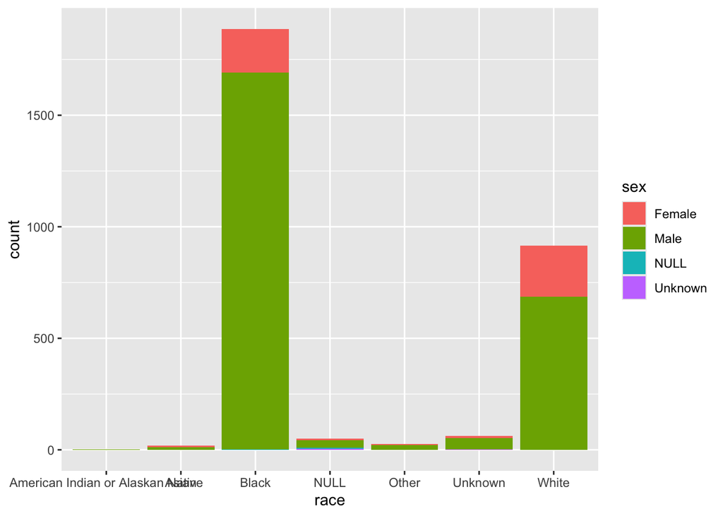

```r
ggplot(data = bps,
       aes(x = race, fill = sex))+
    geom_bar()
```

Yikes!

Here’s a work-around from [stack overflow](https://stackoverflow.com/questions/21878974/wrap-long-axis-labels-via-labeller-label-wrap-in-ggplot2)

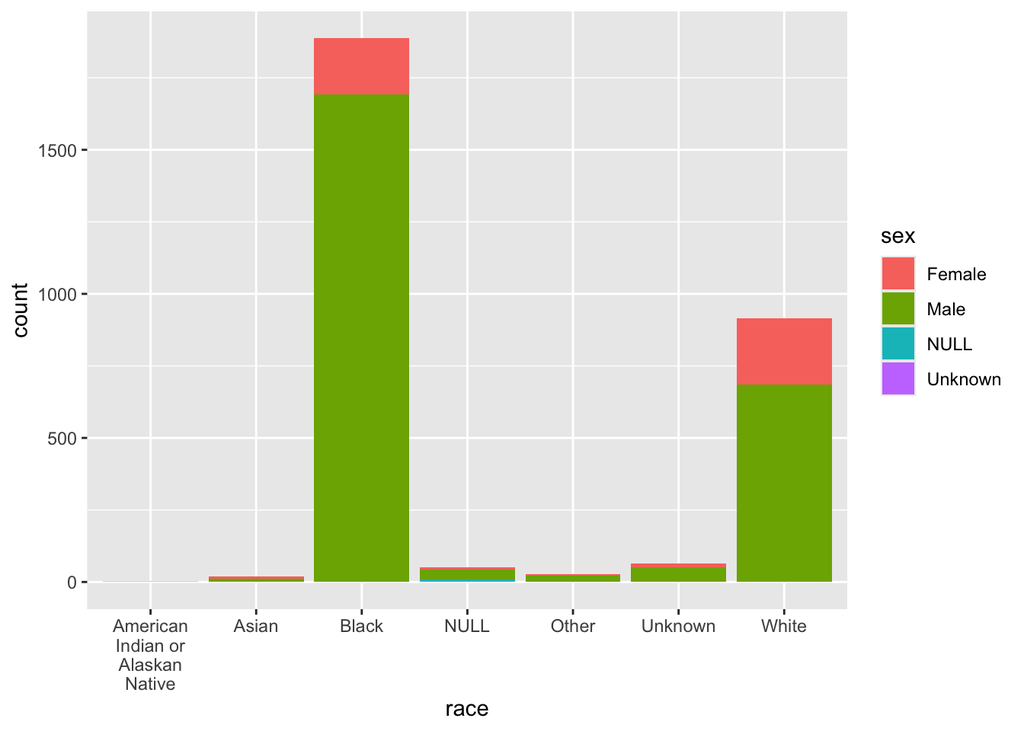

```r
ggplot(data = bps,
       aes(x = race, fill = sex))+
    geom_bar() +
  scale_x_discrete(labels = function(x) str_wrap(x, width = 10))
```

I know, I know, … but alphabetical order makes this ugly too. Can’t we order this by largest to smallest size for the groups?

Yes, but again, it involves a little extra coding. In this case, we can use something from the tidyverse. Here is the code, but it probably won’t make much sense for another few weeks. Just giving you a preview!

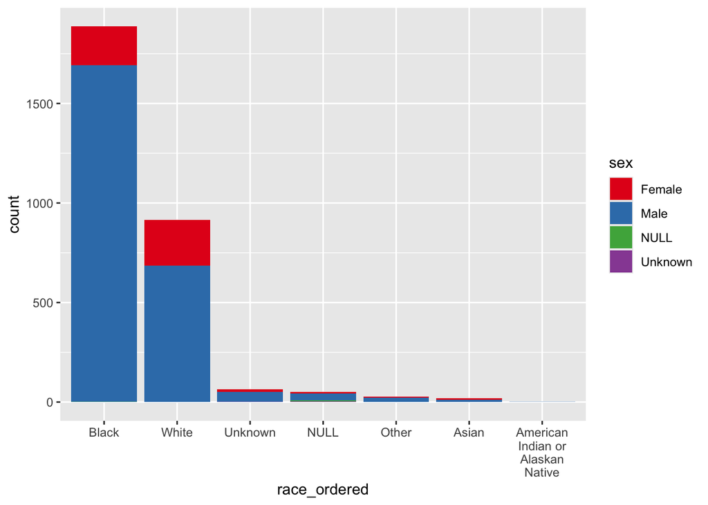

```r
bps %>%
    # We can use mutate to "recreate" the race variable, but order
    # the factor levels by frequency
    mutate(
    race_ordered = fct_infreq(race)
    ) %>%

    # now we create our plot (This is the original code from above.)
    ggplot(data = .,
       aes(x = race_ordered, fill = sex))+
    geom_bar() +
  scale_x_discrete(labels = function(x) str_wrap(x, width = 10))+

    # change color scheme for good measure
    scale_fill_brewer(palette = "Set1")
```